# RELIGION AND ATTITUDE TOWARDS EUTHANASIA

Francesca Martinoli, Simone Travaglini

## Introduction

In this little project we want to investigate how religion impacts the attitude towards euthanasia. **Euthanasia**, also knows as mercy killing, **is a legal,ethical and religious issue**, which is reflected in a number of concepst and legislative solutions around the world. It is precisely on this last point, religion, that this paper wants to focus. The approach towards euthanasia by the main modern religions is certainly conflicting and usually reject this practice. In a letter written by Samaritanus bonus of the Vatican Congregation, it is reported that “the Church believes it must reiterate as a definitive teaching that euthanasia is a crime against human life because, by such an act, a man chooses to directly cause the death of another innocent human”. Unlike the approach of those in favour of this practice, euthanasia is directly compared to murder. Not only Christianity, but also Islam expressly forbids the use of this practice. Azza Hassan, of the National Center for Cancer Care and Research, Doha (Qatar), says that: “Euthanasia, a practice accepted in the West countries, is not permissible in Muslim countries”; on the contrary, it is viewed “with great fear”.

The dataset at our disposal helps us to see what the reference values of the people subjected to the questionnaire are, so we are going to relate a variable concerning religion and one about euthanasia. The purpose of this is to see if those who identify themselves as religious tend to reject the use of this practice, following the concepts of the religious institutions.

## Our variables

In order to investigate the impact of religion on the attitude towards euthanasia, we choose to use the data from the European Values Study - wave 2017. The **European Values Study** is a research program on basic human values (for more information:[European Values Study](https://europeanvaluesstudy.eu/)).

We decided to use the variable *v6*, which contains the answers to the question Q1 “How important it is in your life: religion”.

The values of the variable *v6* are:

- *1 = very important*
- *2 = Quite important*
- *3 = Not important*
- *4 = Not at all important*
  - *-2 = no answer*
  - *-1 = don’t know*

We decide to recode this variable into the variable *imp_rel* in which we set the values *-2* and *-1* as missing, and inverted the values of the original variable in order to have an increasing scale from *1 = “Not at all important”* to *4 = “very important”*.

Then, we choose as dependent variable the variable *v156* which contains the answers to the question Q44H “Please tell me whether you think it can always be justified, never be justified, or something in between: euthanasia”. The variable contains values from *1 = “never”* to *10 = “always”*. We choose to recode also this variable so we can set the values *-2 = “no answer”* and *-1 = “don’t know”* as missing; the other values remain unchanged.

## Results

To perform our analysis we started by looking at the distribution of the independent variable *imp_rel*: the bar chart below shows the frequencies for the variable “how important is religion for you,” in ascending order.

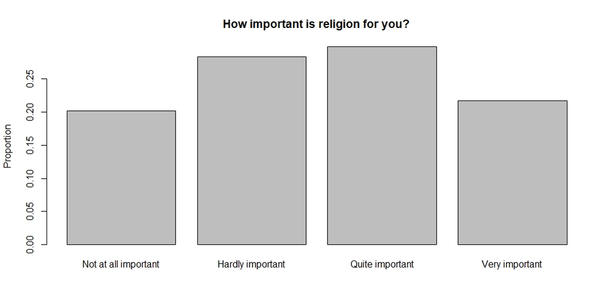

Source:https://github.com/DataAccess2020/CE1_martinoli_travaglini/blob/main/plots/Bar_religion.jpeg

As we can seen, the two categories in the middle are the most numerous and the mode is “3”, that is “quite important”. This shows us that in the sample, religion is a quite important value.

To looking for an impact of the religion on the attitude towards euthanasia, we compared the means on the variable *jst_eut* for each values of the variable *imp_rel*. For the subjects who retain religion “not at all important” in their life or “not important” the mean of *jst_eut* is respectively 6.89 and 6.19; for who retain religion “quite important” the mean of *jst_eut* decrease to 4.68 and, at last, for who retain religion “very important” in their life the mean is 3.44.

This comparison suggests there is a correlation between the two variables.

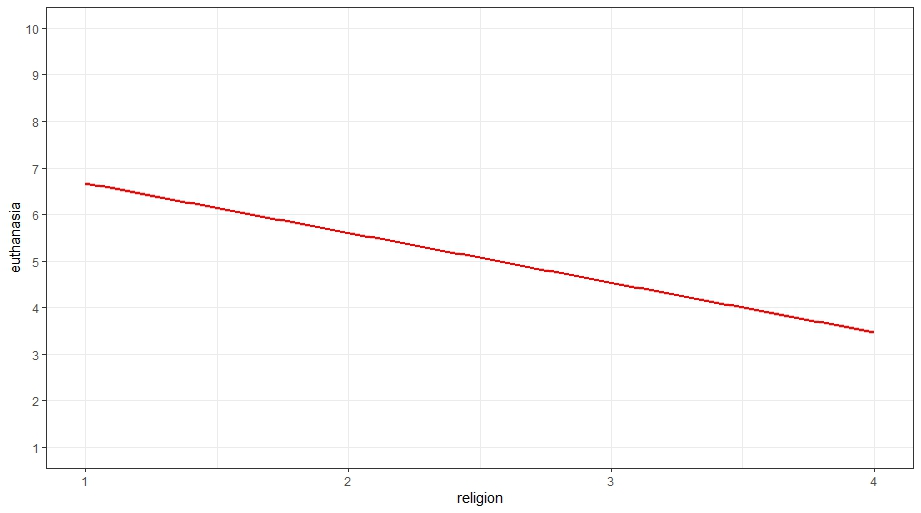

source:https://github.com/DataAccess2020/CE1_martinoli_travaglini/blob/main/plots/regression_plot.jpeg

## Conclusion

Our analysis suggests that there is a negative correlation between the importance of religion in our lives and how much we tend to justify euthanasia. From the comparison of the means and the regression model we can see that the more one considers religion important in his life, the more he will tend to reject recourse to euthanasia and not justify it.

## Sitography

https://www.agensir.it/quotidiano/2018/2/28/cure-palliative-hassan-qatar-islam-non-ammette-eutanasia-ma-considera-molto-virtuoso-il-sollievo-della-sofferenza/

https://www.repubblica.it/esteri/2020/09/22/news/vaticano_no_a_eutanasia_e_suicidio_assistito_sono_crimini_contro_l_umanita_-268163252/